# MLShrinkage

2026-04-28

This analysis pipeline is designed to evaluate the genetic potential of different cotton lines across multiple years and environments. Because agricultural data is inherently noisy—affected by weather, soil, and spatial variations—simple averages aren’t enough.

Here is a step-by-step breakdown of the concepts and goals behind the analysis.

```r
# Install required packages if you don't have them:
# install.packages(c("dplyr", "ggplot2", "lme4", "lmerTest", "readr"))

library(dplyr)
library(ggplot2)
library(lme4)
library(lmerTest)
library(readr)
```

```r
# Load data (equivalent to df_subset)
df_subset <- read_csv("~/Documents/githubdir/DataIntellEngine/data_catalog/example_data/cottonMultiStageFieldData.csv")
print(df_subset)
```

```
## # A tibble: 150,000 × 9
##    Batch  Year Location   Rep Cross  Line   Yield Environment GxE
##    <dbl> <dbl>    <dbl> <dbl> <dbl> <dbl>   <dbl> <chr>       <chr>
##  1  2016  2022        0     0     0     0 -1.03   2022_0      0_2022_0
##  2  2016  2022        0     0     0     1 -1.30   2022_0      1_2022_0
##  3  2016  2022        0     0     0     2 -0.0747 2022_0      2_2022_0
##  4  2016  2022        0     0     0     3  0.0683 2022_0      3_2022_0
##  5  2016  2022        0     0     0     4 -2.41   2022_0      4_2022_0
##  6  2016  2022        0     0     0     5  1.89   2022_0      5_2022_0
##  7  2016  2022        0     0     0     6  1.70   2022_0      6_2022_0
##  8  2016  2022        0     0     0     7 -0.415  2022_0      7_2022_0
##  9  2016  2022        0     0     0     8  0.436  2022_0      8_2022_0
## 10  2016  2022        0     0     0     9  0.105  2022_0      9_2022_0
## # ℹ 149,990 more rows
```

```r
# Ensure categorical variables are factors
df_subset = droplevels(df_subset[df_subset$Line %in% sample(df_subset$Line,1200),])
df_subset$Line <- as.factor(df_subset$Line)
df_subset$Environment <- as.factor(df_subset$Environment)
df_subset$Batch <- as.factor(df_subset$Batch)
df_subset$Cross <- as.factor(df_subset$Cross)
```

### Step 1: Estimating Line Performance (BLUEs vs. BLUPs)

The core of this analysis is figuring out the “true” yield potential of each cotton line. The script calculates this in two different ways to compare them:

- **BLUEs (Best Linear Unbiased Estimators):** This approach treats the cotton `Line` as a **fixed effect**. It estimates the yield of a specific line using *only* the data collected for that specific line, adjusting for the environment.
  - *Pros:* It provides an unbiased estimate based strictly on observed data.
  - *Cons:* If a line was only tested in one or two environments, a lucky (or unlucky) weather event can heavily skew its BLUE estimate, making it appear artificially amazing or terrible.
- **BLUPs (Best Linear Unbiased Predictors):** This approach treats the `Line` as a **random effect**. It assumes that all the cotton lines are drawn from a larger population with a normal distribution of traits.
  - *Pros:* BLUPs “borrow strength” from the whole dataset. If a line has very little data and an extreme yield, the BLUP will pull (or “shrink”) that estimate back toward the population average. This makes BLUPs much more conservative and reliable for future predictions.

### Step 2: Variance Components and G×E Interaction

A major challenge in plant breeding is that a cotton line might perform incredibly well in a wet year (Environment A) but fail completely in a dry year (Environment B). This is called **Genotype × Environment (G×E) Interaction**.

By fitting a mixed model with `(1|Line) + (1|Environment) + (1|GxE)`, the analysis decomposes the total variance in yield into different buckets: 1. **Line Variance:** How much of the yield difference is purely due to genetics? (This is what breeders care about most). 2. **Environment Variance:** How much of the yield difference is just because 2022 was a better year than 2021? 3. **G×E Variance:** How much do specific lines change their ranking depending on the environment? If this variance is high, it means you need to breed specific lines for specific environments, rather than one “universal” line.

```r
# -------------------------------------------------------------------
# 3. Fit Mixed Model (BLUPs and BLUEs)
# -------------------------------------------------------------------

# Option A: BLUEs: Fixed effects only
model_blue <- lm(Yield ~ Line + Environment, data = df_subset)

# Extract BLUEs (coefficients for Line)
blue_coefs <- coef(model_blue)
line_coefs <- blue_coefs[grepl("^Line", names(blue_coefs))]
# Clean up names to just have the Line IDs
names(line_coefs) <- gsub("^Line", "", names(line_coefs))
blue_df <- data.frame(Line = names(line_coefs), BLUE = as.numeric(line_coefs), stringsAsFactors = FALSE)

# Option B: BLUPs: Line as random effect
model_blup <- lmer(Yield ~ Environment + (1|Line), data = df_subset)

# Extract BLUPs (Random effects for Line)
blup_estimates <- ranef(model_blup)$Line
blup_df <- data.frame(Line = rownames(blup_estimates), BLUP = blup_estimates[, 1], stringsAsFactors = FALSE)

# 4. Output Summary
# Merge for comparison
merged <- inner_join(blue_df, blup_df, by = "Line")
print(head(merged))
```

```
##   Line       BLUE       BLUP
## 1    7 -0.6014872  0.5915517
## 2    8 -0.5740293  0.6165335
## 3   10 -1.4970307 -0.2232353
## 4   12 -0.5946226  0.5977973
## 5   18 -1.7952743 -0.4945845
## 6   23 -1.6724947 -0.3828766
```

```r
# -------------------------------------------------------------------
# Step 1 & 2: Add Genotype × Environment Interaction & Variance Components
# -------------------------------------------------------------------

# Create G×E interaction term
df_subset$GxE <- as.factor(paste0(df_subset$Line, "_", df_subset$Environment))

# Fit mixed model in R to estimate variance components
model_varcomp <- lmer(Yield ~ (1|Line) + (1|Environment) + (1|GxE), data = df_subset)
summary(model_varcomp)
```

```
## Linear mixed model fit by REML. t-tests use Satterthwaite's method [
## lmerModLmerTest]
## Formula: Yield ~ (1 | Line) + (1 | Environment) + (1 | GxE)
##    Data: df_subset
##
## REML criterion at convergence: 78006.1
##
## Scaled residuals:
##     Min      1Q  Median      3Q     Max
## -3.9067 -0.5961 -0.0042  0.5934  3.8186
##
## Random effects:
##  Groups      Name        Variance Std.Dev.
##  GxE         (Intercept) 0.2473   0.4972
##  Line        (Intercept) 0.2114   0.4598
##  Environment (Intercept) 0.0295   0.1717
##  Residual                0.4492   0.6703
## Number of obs: 32160, groups:  GxE, 10720; Line, 1072; Environment, 10
##
## Fixed effects:
##             Estimate Std. Error       df t value Pr(>|t|)
## (Intercept) -0.31317    0.05643 10.22722   -5.55 0.000225 ***
## ---
## Signif. codes:  0 '***' 0.001 '**' 0.01 '*' 0.05 '.' 0.1 ' ' 1
```

```r
# Extract variance components
varcomp <- as.data.frame(VarCorr(model_varcomp))
print(varcomp[, c("grp", "vcov", "sdcor")])
```

```
##           grp       vcov     sdcor
## 1         GxE 0.24725411 0.4972465
## 2        Line 0.21138121 0.4597621
## 3 Environment 0.02949777 0.1717491
## 4    Residual 0.44924355 0.6702563
```

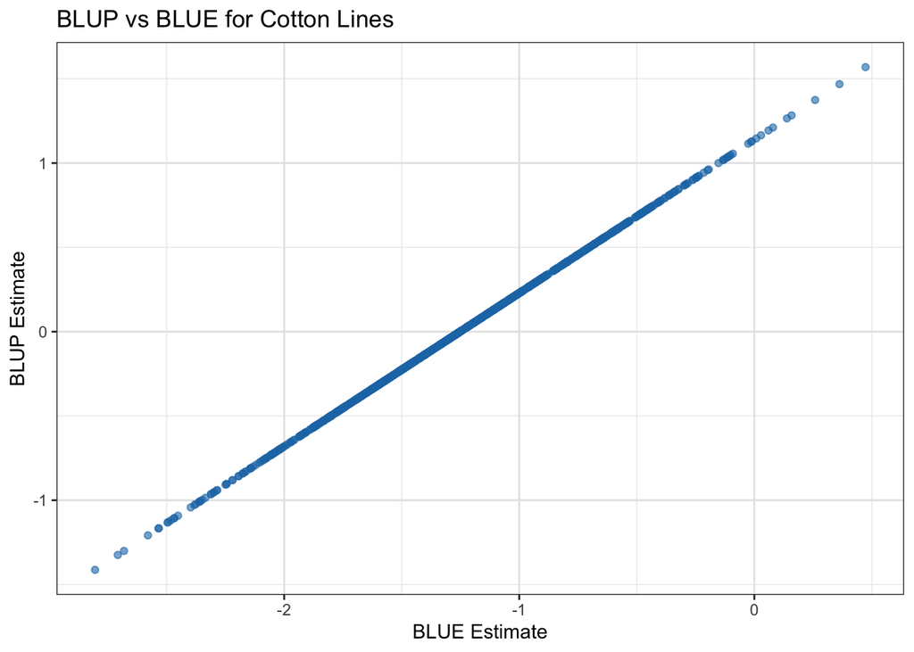

```r
# -------------------------------------------------------------------
# Step 3: Visualize BLUP vs BLUE
# -------------------------------------------------------------------

ggplot(merged, aes(x = BLUE, y = BLUP)) +
  geom_point(alpha = 0.6, color = "#1f77b4") +
  labs(x = "BLUE Estimate", y = "BLUP Estimate", title = "BLUP vs BLUE for Cotton Lines") +
  theme_bw() +
  theme(panel.grid.major = element_line(color = "grey90"))
```

### Step 3: Understanding “Shrinkage”

The analysis explicitly calculates **Shrinkage = BLUE - BLUP**. Shrinkage is a diagnostic tool to see how much the mixed model is “correcting” the raw estimates.

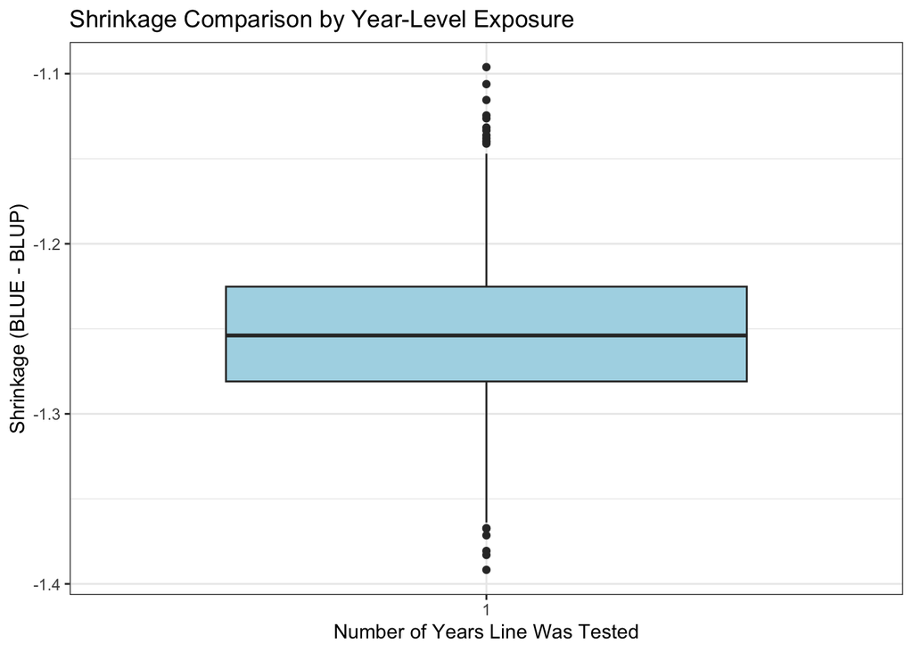

```r
# -------------------------------------------------------------------
# Shrinkage Comparison Across Year Levels
# -------------------------------------------------------------------

# 1. Compute Shrinkage per Line
merged$Shrinkage <- merged$BLUE - merged$BLUP

# 2. Annotate Lines by Year-Level Exposure
line_years <- df_subset %>%
  group_by(Line) %>%
  summarize(Year_Level = n_distinct(Year))

# Merge year-level info into shrinkage dataframe
merged <- inner_join(merged, line_years, by = "Line")

# 3. Visualize Shrinkage by Year-Level
ggplot(merged, aes(x = as.factor(Year_Level), y = Shrinkage)) +
  geom_boxplot(fill = "lightblue") +
  labs(x = "Number of Years Line Was Tested", y = "Shrinkage (BLUE - BLUP)",
       title = "Shrinkage Comparison by Year-Level Exposure") +
  theme_bw()
```

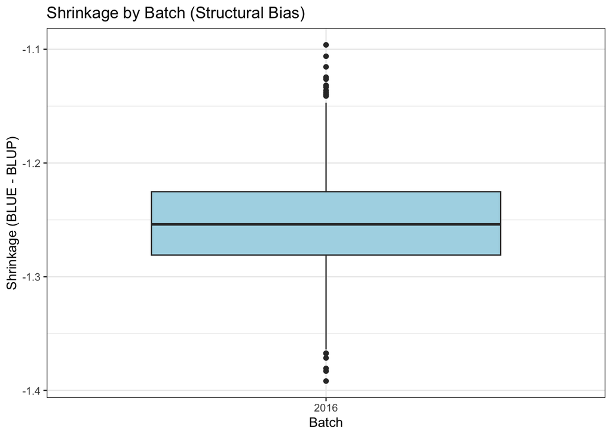

```r
# -------------------------------------------------------------------
# Structural Bias + Predictive Diagnostics
# -------------------------------------------------------------------

# 1. Stratify Shrinkage by Batch and Cross
line_meta <- df_subset %>% distinct(Line, Batch, Cross)
merged <- inner_join(merged, line_meta, by = "Line")

# Boxplot: Shrinkage by Batch
ggplot(merged, aes(x = Batch, y = Shrinkage)) +
  geom_boxplot(fill = "lightblue") +
  labs(x = "Batch", y = "Shrinkage (BLUE - BLUP)", title = "Shrinkage by Batch (Structural Bias)") +
  theme_bw()
```

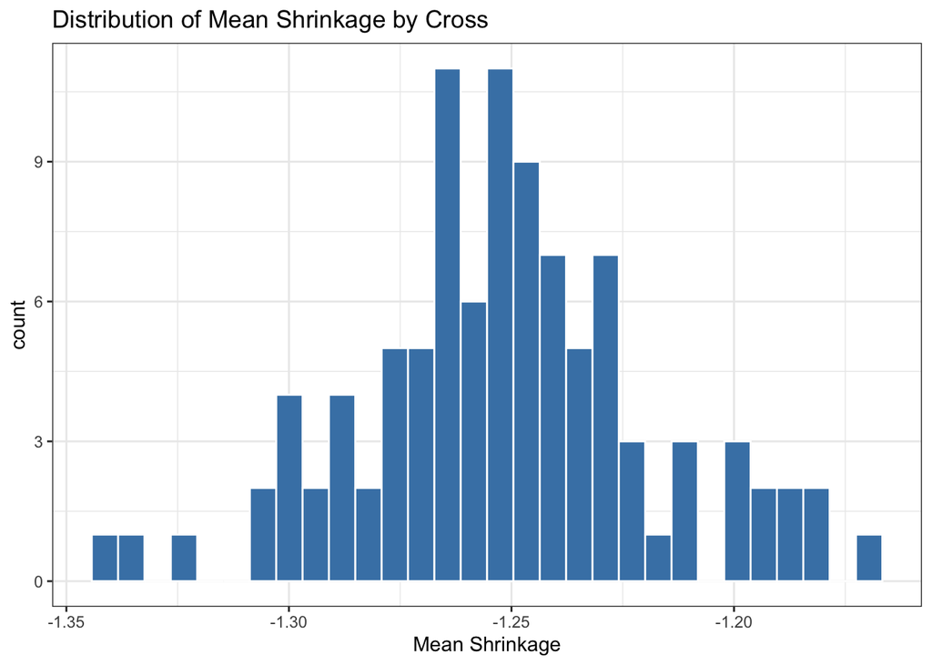

```r
# Optional: Shrinkage by Cross (aggregated)
cross_shrinkage <- merged %>%
  group_by(Cross) %>%
  summarize(Mean_Shrinkage = mean(Shrinkage, na.rm = TRUE))

ggplot(cross_shrinkage, aes(x = Mean_Shrinkage)) +
  geom_histogram(bins = 30, fill = "steelblue", color = "white") +
  labs(x = "Mean Shrinkage", title = "Distribution of Mean Shrinkage by Cross") +
  theme_bw()
```

```r
# -------------------------------------------------------------------
# 2. Overlay Prediction Accuracy
# -------------------------------------------------------------------

# Simulate predicted yield using BLUPs
df_pred <- inner_join(df_subset, merged %>% select(Line, BLUP), by = "Line")

# Calculate R2 manually (equivalent to sklearn's r2_score)
SS_res <- sum((df_pred$Yield - df_pred$BLUP)^2, na.rm = TRUE)
SS_tot <- sum((df_pred$Yield - mean(df_pred$Yield, na.rm = TRUE))^2, na.rm = TRUE)
r2 <- 1 - (SS_res / SS_tot)

cat(sprintf("Prediction R² using BLUPs: %.3f\n", r2))
```

```
## Prediction R² using BLUPs: 0.160
```

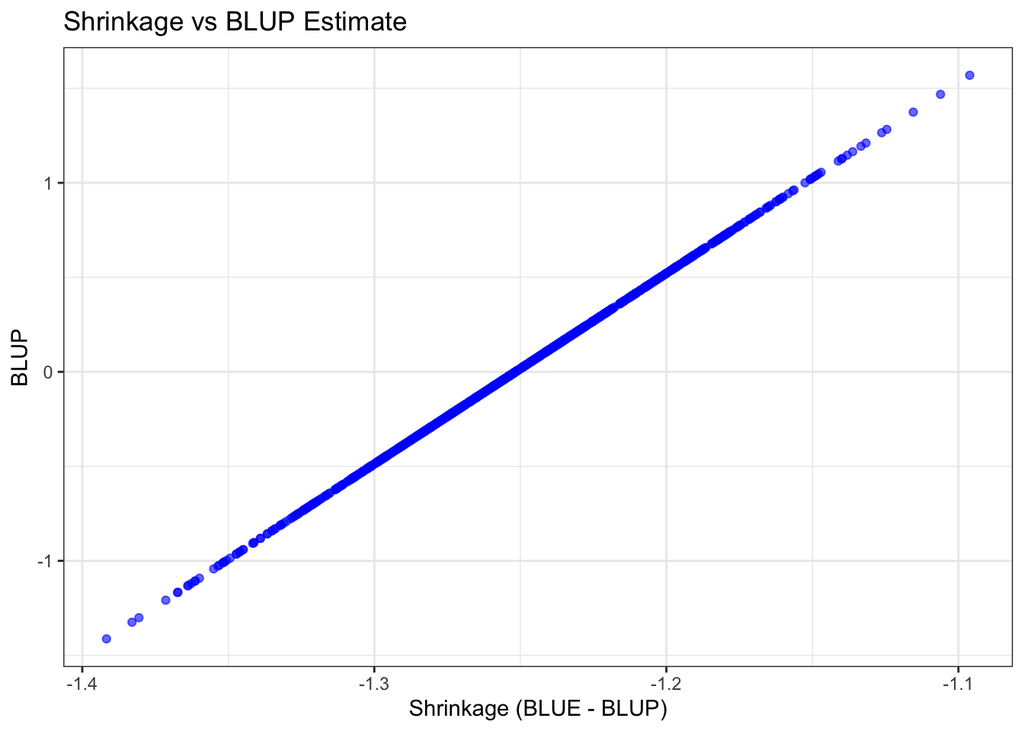

```r
# Overlay shrinkage vs prediction accuracy
ggplot(merged, aes(x = Shrinkage, y = BLUP)) +
  geom_point(color = "blue", alpha = 0.6) +
  labs(x = "Shrinkage (BLUE - BLUP)", y = "BLUP", title = "Shrinkage vs BLUP Estimate") +
  theme_bw()
```

### Step 4: Structural Bias & Predictive Diagnostics

The final step ensures the model’s assumptions are holding up and that the results are practical for real-world selection.

- **Structural Bias (Batch/Cross checks):** The script plots shrinkage against experimental `Batches` and genetic `Crosses`. If one batch has consistently high shrinkage, it indicates an experimental flaw—perhaps that batch was planted late or suffered from uneven field conditions, meaning the model trusts that data less.
- **Prediction Accuracy ($R^2$):** This measures how much of the actual observed yield variance is explained by your final BLUP estimates.
- **Rank Recovery (Spearman Rank):** This is arguably the most important metric for decision-makers. It ranks all the cotton lines from best to worst using BLUEs, and then again using BLUPs, and correlates them. If the correlation is very high (e.g., > 0.90), it means that regardless of the statistical method used, you are going to select the same top 10 lines for advancement. If it is low, it means the BLUP adjustment is heavily altering your selection decisions, likely saving you from advancing “lucky” lines.

```r
# -------------------------------------------------------------------
# 3. Rank Recovery Across Years
# -------------------------------------------------------------------

# Rank lines by BLUE and BLUP
merged$Rank_BLUE <- rank(merged$BLUE)
merged$Rank_BLUP <- rank(merged$BLUP)

# Spearman correlation (equivalent to scipy's spearmanr)
rho <- cor(merged$Rank_BLUE, merged$Rank_BLUP, method = "spearman")
cat(sprintf("Spearman Rank Correlation (BLUE vs BLUP): %.3f\n", rho))
```

```
## Spearman Rank Correlation (BLUE vs BLUP): 1.000
```

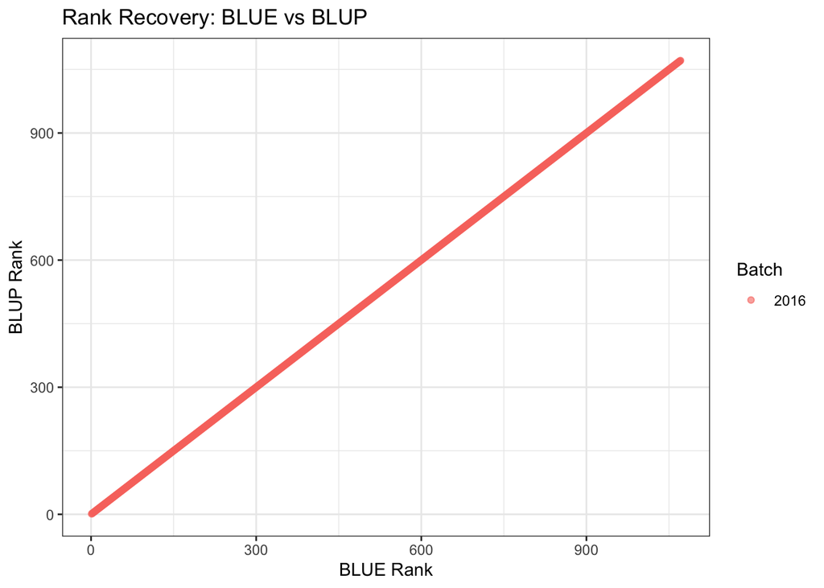

```r
# Rank recovery plot
ggplot(merged, aes(x = Rank_BLUE, y = Rank_BLUP, color = Batch)) +
  geom_point(alpha = 0.6) +
  labs(x = "BLUE Rank", y = "BLUP Rank", title = "Rank Recovery: BLUE vs BLUP") +
  theme_bw()
```